# Pt1_SimulationExercise

Alex Fleming

1/29/2018

## Exploration of the Exponential Distribution in R - Final Course Project

#### by Alex C. Fleming, student in the JHU Data Science Specialization

## Overview

This document will walk through the analysis of an exponential distribution, and the sample means from it, and serve as a re-inforcement of the central limit theorem. We will compare statistics of the theoretical data and the sample data after 1000 simulations of draws from 40 exponential distributions (in a dataset called “mns”). There will be no variation in the lambda of the exponential simulations.

The exponential distirbution is a function of x and lambda where
$$f(x) = \lambda e^{-\lambda x} \hspace{.3in}
x \ge 0$$

The mean of this distribution is 1/lambda and the variance is 1/lambda^2

## Simulations

```r
knitr::opts_chunk$set(echo = TRUE)
# Basic setup including lambda, data, and the means
lambda <- .2
# Exponential data distribution for comparison
data <- rexp(1000, lambda)
# Create Means simulation
mns <- NULL
for (i in 1 : 1000){
     mns <- c(mns, mean(rexp(40, lambda)))
}
```

The graphs below illustrate the raw distribution vs. the means of repeated distributions

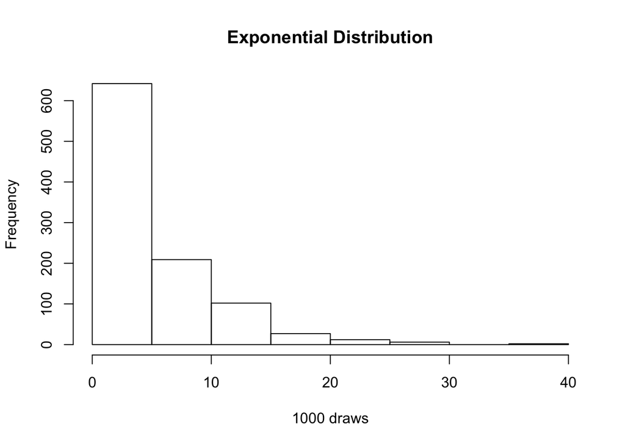

```r
hist(data, main="Exponential Distribution", xlab="1000 draws")
```

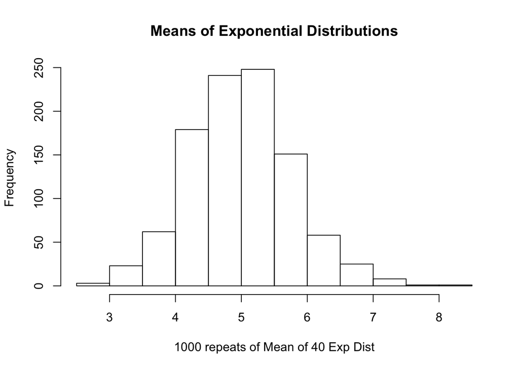

```r
hist(mns, main="Means of Exponential Distributions", xlab="1000 repeats of Mean of 40 Exp Dist")
```

## Sample Mean vs Theoretical Mean

The differences between the sample and theory are small, which does not surprise us with only 1000 simulations. They seem to be close enough to satisfy basic curiousity.

```r
tmu <- 1/lambda
smu <- mean(mns)
diff <- smu-tmu
paste("The difference between the means is", diff, ", the theoretical mean is", tmu, ", and the sample mean is", smu,".")
```

```
## [1] "The difference between the means is -0.00344245030362433 , the theoretical mean is 5 , and the sample mean is 4.99655754969638 ."
```

This is to be expected since the sample is coming from an exponential distirbution.

## Sample Variance vs. Theoretical Variance

The variance of the theory of the exponential distribution

```r
tvar <- 1/(lambda^2)
svar <- var(mns)
diffv <- tvar-svar
paste("The difference between the variances is", diffv, ", the theoretical variance of an exponential distribution is", tvar, ", and the drawn sample variance is", svar)
```

```
## [1] "The difference between the variances is 24.3914276997347 , the theoretical variance of an exponential distribution is 25 , and the drawn sample variance is 0.60857230026532"
```

This is also not a surprising result since the central limit theorem tells us that as you have more and more independent samples from any distribution, the resulting sample is normal, not exponential.

## Distribution

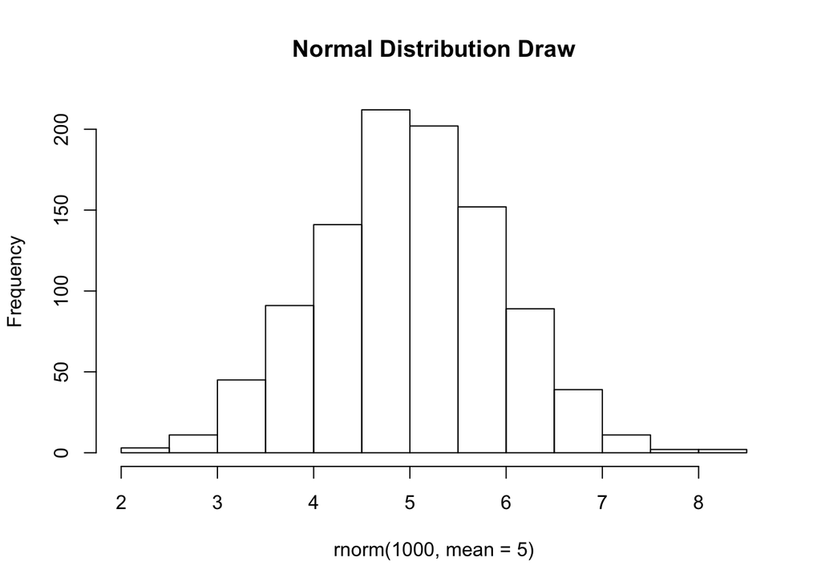

```r
hist(rnorm(1000, mean=5), main="Normal Distribution Draw")
```

```r
nvar <- var(rnorm(1000, mean=5))
paste("Our sample variance from the mns dataset is", svar, "versus the variance of 1000 normal draws of", nvar)
```

```
## [1] "Our sample variance from the mns dataset is 0.60857230026532 versus the variance of 1000 normal draws of 0.935319263062128"
```

We would expect this sample variance to approach as the number of iterations increases, but this shows that our sample is beginning to approximate a normal distribution. This reinforces what we would expect from the central limit theorem.

Contact: alex.c.fleming@gmail.com